# Communicate Data Findings : Loan Data from Prosper by Ilknur Cakir

## Data Overview

This data set contains 113,937 loans with 81 variables on each loan, including loan amount, borrower rate (or interest rate), loan original amount, borrower income, and many others. For this project, I take a subset of features which is 17 variables out of original 81 variables. So the data has 113,937 samples with 17 variables.

```python
# importing necessary libraries
import pandas as pd
import numpy as np
import matplotlib.pyplot as plt
import seaborn as sns
from IPython.display import display

%matplotlib inline
```

I select 17 variables that are given below. I first drop all rows with missing value. One of the variables, namely ProsperScore is credit risk score and ranges from 1 to 10 with 1 representing the worst and 10 representing the best. But there are instances where ProsperScore equals to 11. Assuming it is due to unclean data, I drop all of these instances. Other than that the data is pretty clean and tidy.

```python
# The column names that I will use in the analysis
cols =['Term',
 'BorrowerRate',
 'BorrowerAPR',
 'LenderYield',
 'ProsperScore',
 'ListingCategory (numeric)',
 'BorrowerState',
 'Occupation',
 'EmploymentStatus',
 'EmploymentStatusDuration',
 'InquiriesLast6Months',
 'DebtToIncomeRatio',
 'LoanOriginalAmount',
 'CurrentCreditLines',
 'LoanStatus',
 'StatedMonthlyIncome',
 'DelinquenciesLast7Years']

# Reading the data and take only necessary columns
df = pd.read_csv('prosperLoanData.csv')
df = df[cols]
df.dropna(inplace = True)
df.ProsperScore.unique()
```

```
array([ 7.,  9.,  4., 10.,  2., 11.,  8.,  5.,  3.,  6.,  1.])
```

```python
# Prosper Score is defined in a way thatit ranges from 1 to 10. Drop samples with ProsperScore equals to 11.
# It must be due to unclean data

index = df[df.ProsperScore == 11].index
df.drop(index, inplace = True)
df.shape
dff = df.copy()

# Examining the first few rows of the data
display(dff.head())
```

|  | Term | BorrowerRate | BorrowerAPR | LenderYield | ProsperScore | ListingCategory (numeric) | BorrowerState | Occupation | EmploymentStatus | EmploymentStatusDuration | InquiriesLast6Months | DebtToIncomeRatio | LoanOriginalAmount | CurrentCreditLines | LoanStatus | StatedMonthlyIncome | DelinquenciesLast7Years |
| --- | --- | --- | --- | --- | --- | --- | --- | --- | --- | --- | --- | --- | --- | --- | --- | --- | --- |
| 1 | 36 | 0.0920 | 0.12016 | 0.0820 | 7.0 | 2 | CO | Professional | Employed | 44.0 | 3.0 | 0.18 | 10000 | 14.0 | Current | 6125.000000 | 0.0 |
| 3 | 36 | 0.0974 | 0.12528 | 0.0874 | 9.0 | 16 | GA | Skilled Labor | Employed | 113.0 | 0.0 | 0.15 | 10000 | 5.0 | Current | 2875.000000 | 14.0 |
| 4 | 36 | 0.2085 | 0.24614 | 0.1985 | 4.0 | 2 | MN | Executive | Employed | 44.0 | 1.0 | 0.26 | 15000 | 19.0 | Current | 9583.333333 | 0.0 |
| 5 | 60 | 0.1314 | 0.15425 | 0.1214 | 10.0 | 1 | NM | Professional | Employed | 82.0 | 0.0 | 0.36 | 15000 | 21.0 | Current | 8333.333333 | 0.0 |
| 6 | 36 | 0.2712 | 0.31032 | 0.2612 | 2.0 | 1 | KS | Sales - Retail | Employed | 172.0 | 0.0 | 0.27 | 3000 | 10.0 | Current | 2083.333333 | 0.0 |

### Stated Monthly Income

The distribution of monthly income is given below. It is not distributed normally and symmetrically and it is highly right-skewed. Monthly income of borrowers is lumped between 0 and 10k. Mean is around 5k. Very small percentage of borrowers make more than 20k. Max is at around 483k.

Log transformation is necessary to make it look more like normally distributed and symmetric. The transformation is done below and new variable is named 'income_trans'. The distributions of stated monthly income and transformed income are given in the upcoming two cells below.

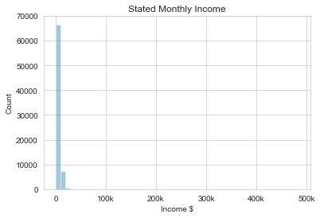

```python
# Visualizing stated monthly income before transformation
sns.set_style('whitegrid')
sns.distplot(dff['StatedMonthlyIncome'], kde = False);
plt.xlabel('Income $');
plt.ylabel('Count')
plt.title('Stated Monthly Income');
ticks = np.arange(0, 500000+100000, 100000)
labels = ['0', '100k', '200k', '300k', '400k', '500k'];
plt.xticks(ticks, labels);
```

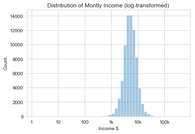

```python
# Applying log-transformation to StatedMonthlyIncome
# and visualizing the new variable income_trans

dff['Income_trans'] = dff['StatedMonthlyIncome'].apply(lambda x: np.log10(x+1))

sns.distplot(dff['Income_trans'], kde = False);
plt.title('Distribution of Montly Income (log-transformed)');
plt.xlabel('Income $')
ticks = np.arange(0, 5+1, 1)
labels = ['1', '10', '100', '1k', '10k', '100k']
plt.xticks(ticks, labels);
plt.ylabel('Count');
```

It is important to loook at histogrms of variables where it is possible to be able to better understand the data. I plot the histograms of BorrowerRate, LenderYield, ProsperScore, DebtToIncomeRatio, DelinquenciesLast7Years and LoanOriginalAmount.

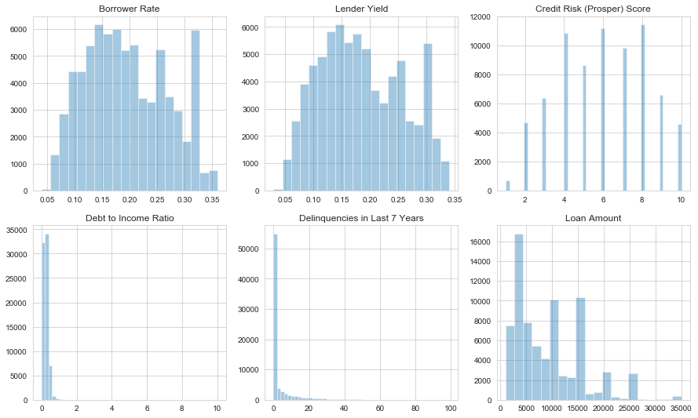

```python
# Plotting histograms of continuous variables in the dataset

plt.clf()
f, axes = plt.subplots(2, 3, figsize = (15,9), sharex = False);

sns.distplot(dff['BorrowerRate'], kde= False, bins = 20, ax= axes[0,0]);
axes[0,0].set_title('Borrower Rate'), axes[0,0].set_xlabel('')
#sns.distplot(dff['BorrowerAPR'], kde= False, bins = 20, ax= axes[0,1]);
sns.distplot(dff['LenderYield'], kde= False, bins = 20, ax= axes[0,1]);
axes[0,1].set_title('Lender Yield'), axes[0,1].set_xlabel('')
sns.distplot(dff['DebtToIncomeRatio'], kde= False, bins = 50, ax= axes[1,0]);
axes[1,0].set_title('Debt to Income Ratio'), axes[1,0].set_xlabel('')
#axes[1,0].set_xlim(0, 1);
sns.distplot(dff['ProsperScore'], kde= False, ax= axes[0,2]);
axes[0,2].set_title('Credit Risk (Prosper) Score'), axes[0,2].set_xlabel('')
sns.distplot(dff['DelinquenciesLast7Years'], kde= False, ax= axes[1,1]);
axes[1,1].set_title('Delinquencies in Last 7 Years'), axes[1,1].set_xlabel('')
#sns.distplot(np.log(dff['LoanOriginalAmount']), kde= False, bins = 20, ax= axes[1,2]);
sns.distplot(dff['LoanOriginalAmount'], kde= False, bins = 20, ax= axes[1,2]);
axes[1,2].set_title('Loan Amount'), axes[1, 2].set_xlabel('');
```

Prosper Score gives the risk score of the borrower. It ranges from 1 to 10 with 1 boing the lowest and 10 being the best score. The distribution has three peaks at the values 4, 6 and 8.

Debt to income ratio is roughly between 0 and 10. There is a small number of samples with debt to income ratio greater than 1. But it goes to as high as 10. The distribution is very right-skewed.

Most samples have no delinquency in the last 7 years. For a small subset of samples, this number can be as high as 80 or 100. The lump is between 0 and 30 in the distribution.

There are spikes at points 5k, 10k, 15k, 20k and 25k in the distribution of loan original amount. It peaks at one spike and decreases until the next one and there it peaks again. It is also slightly right-skewed.

I also add the violinplots of these variables. It gives a different perspective.

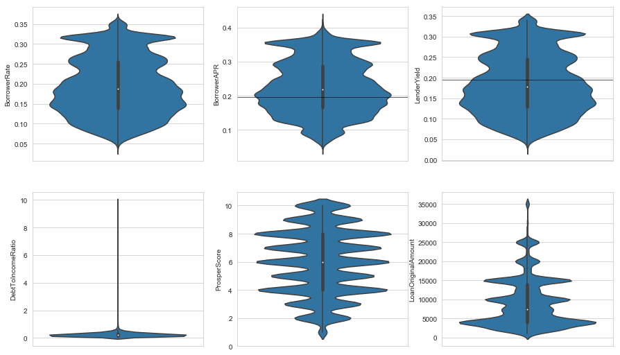

```python
# PLotting violin plots of 6 variables

plt.clf()
f, axes = plt.subplots(2, 3, figsize = (15,9), sharey = False)

sns.violinplot(y = dff['BorrowerRate'], ax= axes[0,0]);
sns.violinplot(y = dff['LenderYield'], ax= axes[0,2]);
axes[0,2].axhline(dff.BorrowerRate.mean(), color = 'black', linewidth = 0.6);
sns.violinplot(y = dff['BorrowerAPR'], ax= axes[0,1]);
axes[0,1].axhline(dff.BorrowerRate.mean(), color = 'black', linewidth = 0.6);
sns.violinplot(y = dff['DebtToIncomeRatio'], ax= axes[1,0]);
sns.violinplot(y = dff['ProsperScore'], ax= axes[1,1]);
sns.violinplot(y = dff['LoanOriginalAmount'], ax= axes[1,2]);
```

Now let's look at other variables that I will not use in coming parts of the project but are helpful to learn about the data. These are Listing Category, BorrowerState, Occupation and Employment Status.

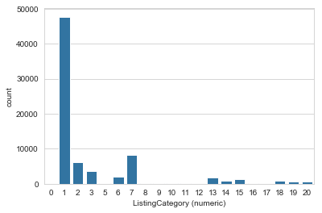

```python
# Countplot of ListingCategory

base_color = sns.color_palette()[0]
sns.countplot(data = dff, x= 'ListingCategory (numeric)',color = base_color);
```

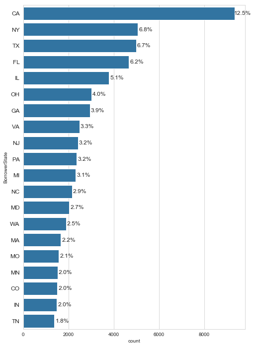

```python
# Countplot of BorrowerState and some polishing on the graph

plt.figure(figsize = (8,12))
order = dff.BorrowerState.value_counts().sort_values(ascending = False)[:20].index
sns.countplot(data = dff, y = 'BorrowerState', color = base_color, order = order);
plt.yticks(fontsize = 12);


counts = dff.BorrowerState.value_counts().sort_values(ascending = False)[:20]
total = dff.BorrowerState.shape[0]

for i in range(counts.shape[0]):
    share = counts[i]*100/total
    plt.text(counts[i]+350, i, '{:0.1f}%'.format(share),va = 'center', ha = 'center',fontsize = 12)
```

The graph of states loans are used in are given above. Most loans are used in California, New York, Texas and Florida.

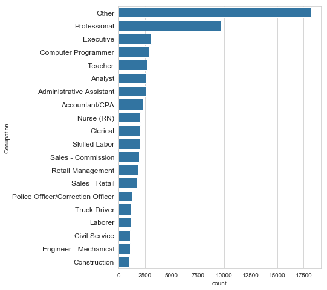

```python
# Countplot of Occupation

plt.figure(figsize = (6, 8))
order_occ = dff.Occupation.value_counts().sort_values(ascending = False)[:20].index

sns.countplot(data = dff, y = 'Occupation', color = base_color, order= order_occ);
plt.yticks(fontsize = 12);
```

The graph of occupation of borrowers shows that many borrowers have a job in 'other' and 'professonal' categories. The graph below says that majority of borrowers are currently employed and work full-time. The mean of employment duration s 73 months. Min value is 0, and max is close to 700 months. The employment duration distribution for different employment status is given below. Borrowers full-time working work for longer duration than borrowers working part-time.

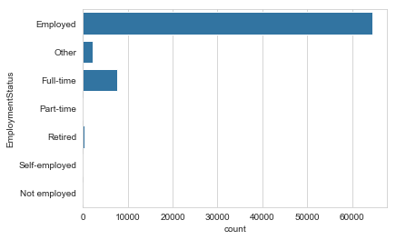

```python
# Countplot of EmploymentStatus
sns.countplot(data = dff, y = 'EmploymentStatus', color = base_color);
```

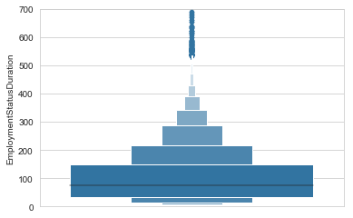

```python
sns.boxenplot(data = dff, y = 'EmploymentStatusDuration');
plt.ylim(0, 700);
```

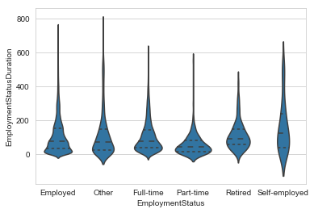

```python
# looking at employment status duration distribution for different employment statutes
# I first eliminate 'not employed' samples

plot_data = dff[dff.EmploymentStatus != 'Not employed']
sns.violinplot(y = plot_data['EmploymentStatusDuration'], inner = 'quartile', x = plot_data['EmploymentStatus'], color = base_color);
```

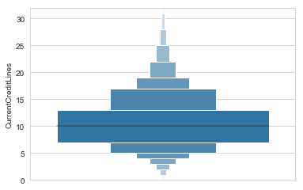

```python
# Distribution of CurrentCreditLines

sns.boxenplot(data = dff, y = 'CurrentCreditLines');
plt.ylim(0, 32);
```

InquiriesLast6Months gives how many times a borrower inquiries his own credit risk score. There are many outliers. It is plaussible to think that borrowers who want to or need to improve their risk score have higher motivation to check their own risk scores. Regression plot says the same; as prosperscore decreases the number of inquiries increases.

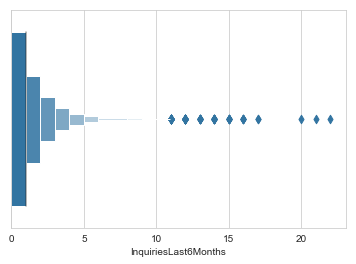

```python
# Boxen plot of InquiriesLast6Months
sns.boxenplot(dff['InquiriesLast6Months']);
```

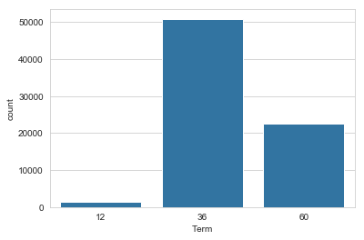

```python
# countplot of Term
base_color = sns.color_palette()[0]
sns.countplot(data = dff, x = 'Term', color = base_color);
```

Most of the loans taken out are with 36-month terms. Then comes 60-month-term loan. The smallest share belongs to loans with 12 months.

## Bivariate Plots

I mainly try to understand how 3 variables namely Prosper Score, Borrower Rate and Loan Amount interact and change with other variables. In this section there are bivariate plots giving the relationship between credit risk score (Prosper Score) and other variables. I put bivariate plots related to the other two, Borrower Rate and Loan Amount under the sections seperated with relevant questions.

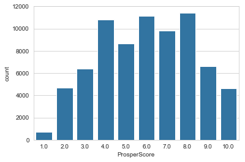

```python
# Countplot of ProsperScore
sns.countplot(data = dff, x= 'ProsperScore', color = base_color);
```

First I try to see the distribution of risk score. 1 is the worst and 10 is the best in this scale. Count plot shows that there are most people with credit risk score 4, 6 and 8, so we have 3 peaks. Let's look at the relationship between credit score and stated monthly income.

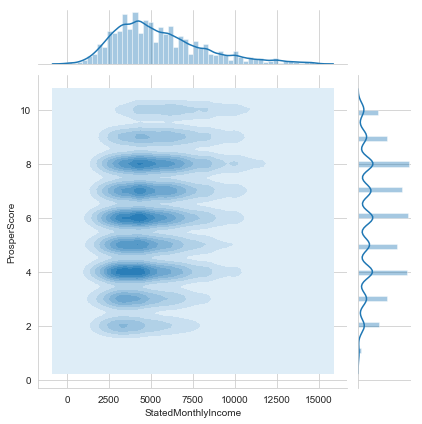

```python
# JointGrid of credit risk score and monthly income.
# On edges, distribution of corresponding variable is given ,
# at the intersection kdeplot is given.

plot_data = dff[dff.StatedMonthlyIncome < 15000]
g = sns.JointGrid(data = plot_data, x = 'StatedMonthlyIncome', y = 'ProsperScore')
g = g.plot_joint(sns.kdeplot, shade = True)
g = g.plot_marginals(sns.distplot)
```

There seems to be positive correlation between income and risk score. It is easier to put risk on x-axis, but most probably causation works the other way around. As income increases credit score improves. It is seen below, average monthly income increases with increasing credit risk score.

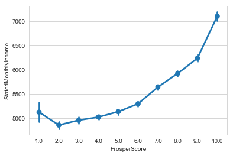

```python
# Average monthly income in samples with different credit risk score

sns.pointplot(data = dff[dff.StatedMonthlyIncome < 15000], x= 'ProsperScore', y = 'StatedMonthlyIncome');
```

Below is the regression plot of risk score and DelinquenciesLast7Years.

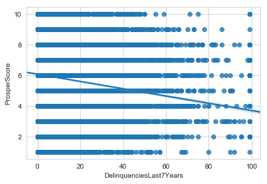

```python
# Regression plot of DelinquenciesLast7Years and ProsperScore showing the relationship between two.

sns.regplot(data = dff, x = 'DelinquenciesLast7Years', y = 'ProsperScore');
```

As the number of delinquencies in the last 7 years increases, credit score decreases. In regression plot, the slope of the line is negaative. It is also seen by the point plot below. The average number of delinquencies in the sample with the same credit score decreases as the score increases (most probably causation works the other way). The average risk score in the samples with different risk score is given in pointplot below. It is seen that there is a negative correlation between risk score and the number of delinquencies last 7 years.

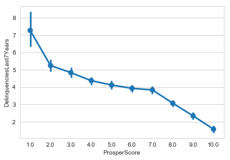

```python
# Point plot of Prosper Score and DelinquenciesLast7Years
sns.pointplot(data = dff, x = 'ProsperScore', y = 'DelinquenciesLast7Years');
```

Inquiries in the last 6 months is the number of times the borrower inquiries his credit score in the last 6 months. It is plausible that if you have some problems with your score or do not have a credit score as high as you want, you have motivation to check your score frequently to see what it is and how it changes. So I would expect to see a negative correlation between two. Regression plot and point plot say the same. The average risk score deteriorates as the number of inquiries increases.

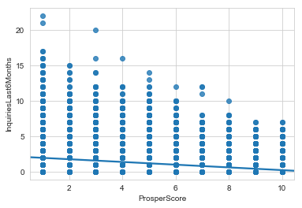

```python
# Regression PLot of risk score and InquiriesLast6Months
sns.regplot(data = dff, x = 'ProsperScore', y = 'InquiriesLast6Months');
```

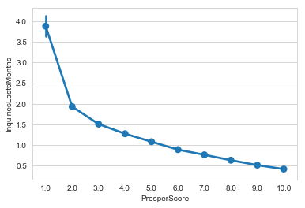

```python
# Point plot of risk score and InquiriesLast6Months
sns.pointplot(data = dff, x = 'ProsperScore', y = 'InquiriesLast6Months');
```

The next variable is DebtToIncomeRatio. It is basically the ratio of borrower's total debt to his income. I want to look at the relationship between two by plotting 2 dimensiona histogram. From histogram, it is seen that there is negative correlation between debt to income ratio and credit score. Box plot below says that as score increases mean debt ratio gets smaller. And there are many outliers at highest credit risk scores like 8, 9 and 10.

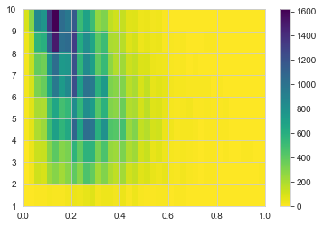

```python
# 2 dimensional histogram of riskscore and DebtToIncomeRatioby setting the bins for x and y axis
x_bins = np.arange(0, 1+0.025, 0.025)
y_bins = np.arange(1,11)
plt.hist2d(data = dff, y = 'ProsperScore', x = 'DebtToIncomeRatio', bins = [x_bins, y_bins], cmap= 'viridis_r');
plt.colorbar();
```

```
(0, 1.5)
```

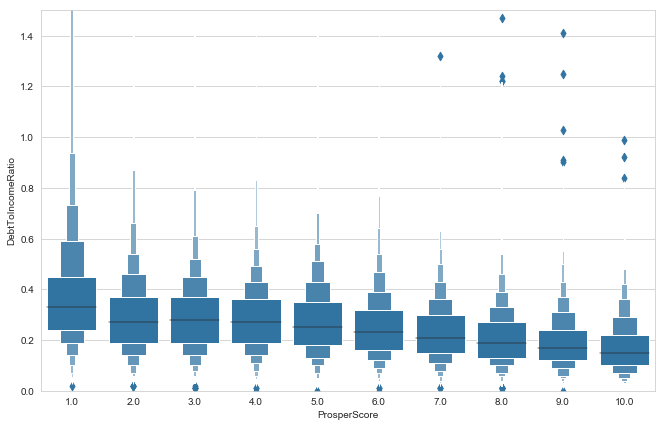

```python
# Boxen plot of risk score at different debttoincome ratios.
plt.figure(figsize = (11,7))
sns.boxenplot(data = dff, x = 'ProsperScore', y = 'DebtToIncomeRatio', color = base_color);
plt.ylim(0, 1.5)
```

Below is the 2d histogram of risk score and current credit lines. The darkest parts of the heatmap shows a steady line. So no clear relationship between two is seen here. The plot is indecisive about the relationship between two. Pointplot says the mean number of credit lines does not change much as risk score improves.

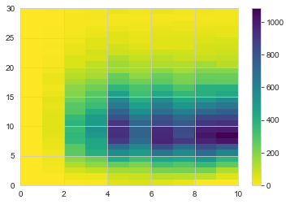

```python
y_bins = np.arange(0, 30 + 1, 1)
x_bins = np.arange(0,11, 1)
plt.hist2d(data = dff, x = 'ProsperScore', y = 'CurrentCreditLines', bins = [x_bins, y_bins], cmap= 'viridis_r');
plt.colorbar();
```

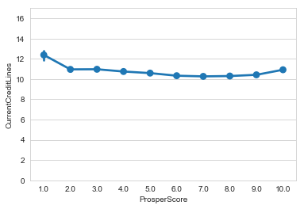

```python
# The plot of average risk score for different values of CurrentCreditLines
sns.pointplot(data = dff, x = 'ProsperScore', y = 'CurrentCreditLines');
plt.ylim(0, 17);
```

To sum up; the credit risk score increases (improves, the higher the better) as

- stated monthly income increases,
- the number of delinquencies in the last 7 years decreses,
- the number of times the borrower checks his score in the last 6 mmonths decreases,
- the debt to income ratio decreases,

There is no clear relationship between credit risk score and the number of current credit lines.

Next I will try to explore Term variable. Term is the duration over which the borrowers is supposed to pay back the loan. Most loans are 36 month loans. There is a very small number of 12 month loans. It is plausible to expect the borrower rate to increase as term increases holding other things equal. Below are given the graph of borrower rate, apr and lender yield changing with term.

it is interesting to see that the average rate of 36 month loans is greater than the average rate of 60 month loans. It might be the case that generally 60 month loans are solely given to people with high credit scores so it makes the average borrower rate smaller. We will see the reason when we look at multivariate graphs.

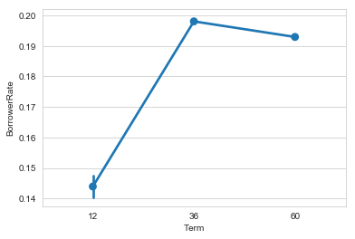

```python
# Borrower Rate vs. Term

sns.pointplot(x = dff['Term'], y = dff['BorrowerRate']);
```

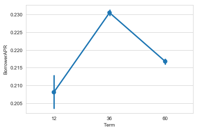

```python
# Borrower APR vs Term

sns.pointplot(data = dff, x = 'Term', y = 'BorrowerAPR');
```

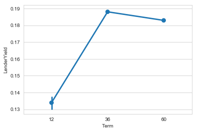

```python
# Lender Yield vs. Term
sns.pointplot(data = dff, x = 'Term', y = 'LenderYield');
```

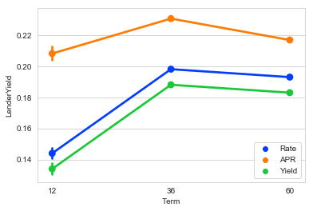

```python
# Borrower rate, APR and Lender Yield are shown on the same graph for different Term values to
# see how they change as Term changes and how this change compares to others.

colors = sns.color_palette('bright', 3)
sns.pointplot(data = dff, x = 'Term', y = 'BorrowerRate', color = colors[0]);
sns.pointplot(data = dff, x = 'Term', y = 'BorrowerAPR', color = colors[1]);
sns.pointplot(data = dff, x = 'Term', y = 'LenderYield', color = colors[2]);


legend_obj = []
for i in colors:
    legend_obj.append(plt.scatter([], [], color = i))
plt.legend(legend_obj, ['Rate', 'APR', 'Yield']);
```

Next, I will try to explore how loan amount changes with term. I plot below violin plot of loan amount at different term values. According to the graph, the average loan amount of 12-month loans is smaller than the average of 36-month loans and highest average loan amount belongs to 60-month loans which totally makes sense. If loan amount is large, borrower wants to pay back in a longer period of time as monthly payments would be large that he would be having difficulty paying back if it was shorter duration loan.

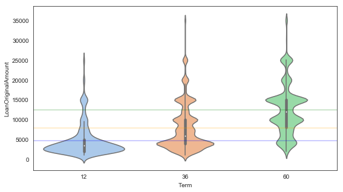

```python
# The violin plot of loan amount for different term values. I also add horizontal lines showing mean values
# of loan amounts in the corresponding colors to make comparison easier.

sns.set_style('white')
plt.figure(figsize = (9,5))
sns.violinplot(data = dff, y = 'LoanOriginalAmount', x = 'Term', palette= 'pastel');
plt.axhline(dff[dff.Term == 12].LoanOriginalAmount.mean(), color = 'blue', linewidth = 0.4);
plt.axhline(dff[dff.Term == 36].LoanOriginalAmount.mean(), color = 'orange', linewidth = 0.4);
plt.axhline(dff[dff.Term == 60].LoanOriginalAmount.mean(), color = 'green', linewidth = 0.4);
```

In the upcoming two sections, I try to answer two questions:

- What affects the borrower's APR or interest rate?
- Are there differences between loans depending on how large the original loan amount was?

To be able to answer these questions, I will look at bivariate and multivariate graphs of borrower rate (and loan amount in the other section) with other variables.

# What affects the borrower’s APR or interest rate?

### Borrower Rate and Income

I expect to see a positive correlation between borrower rate and income. I use regression plot to see the relationship. I use log transformed new variable income_trans instead of original StatedMonthlyIncome. The confidence interval of regression lige gets larger at small and very large incoem values as there is few data points here. Confidence interval is small when there are many samples at the points. It is seen that there is a negative relationship between income and borrower rate. Intrest rate borrower pays decreases with increasing monthly income. It must be so because as income increaases credit score improves and lender charge a lower interest rate to the borrower but we cannot draw this conclusion from the graph. It does not say anything about causation, it says only about correlation.

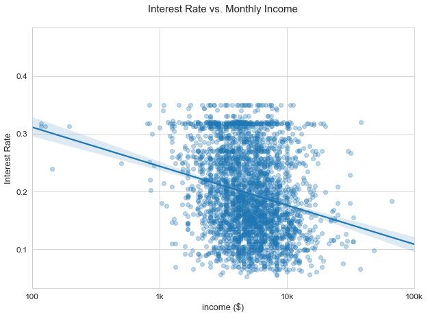

```python
# Regression plot of income and borrower rate. I pick tick values in accordance with
# log-transformed income_trans.

plt.figure(figsize = (10, 7))
plot_data = dff.sample(3000, replace = False)
sns.regplot(data = plot_data, x = 'Income_trans', y = 'BorrowerRate', scatter_kws = {'alpha':0.3, 'edgecolor' : None});
plt.title('Interest Rate vs. Monthly Income\n', fontsize = 15)
ticks = np.arange(2, 5+1, 1)
labels = ['100', '1k', '10k', '100k']
plt.xticks(ticks, labels,fontsize = 12);
plt.yticks(fontsize = 12);
plt.xlabel('income ($)', fontsize = 13)
plt.ylabel('Interest Rate', fontsize = 13);
plt.xlim(2, 5);
```